# Gex

Sandra Erdmann

4 October 2018

CHECK ON THE 23082018 ANCOVA FOR MIXED EFFECTS MODELS LINE 442

# Gene expression project Gex

Which model to choose?

https://help.xlstat.com/customer/en/portal/articles/2062461-which-statistical-model-should-you-choose-?b_id=9283

According to this key I have one dependent or response variable (y), which is my gene expression and which is continuous. Then I have several explainatory or independent (x) variables or predictors (TA, phosphate, nitrate; light, sal, pH, Temp.), which are continous or seen as 4 treatments are categorical.

Variables can be classified as **categorical** (aka qualitative) or **numerical** (aka quantitative). Categorical variables take on values that are names or labels. The color of a ball (e.g., red, green, blue) or the breed of a dog (e.g., collie, shepherd, terrier) would be examples of categorical variables. If I decide for categorical variables, then I should not include TA, NO3 or PO43, since they are numerical. I should focus on sample 380, 380+, 1000 and 1000+ or treatment A, B, C and D or switch to Low and High for both factors.

Either these variables are (a) **several qualitative variables** with several levels, such as combinatory effects of CO2 (2 factors) and nutrient levels (2 factors) on the expression rate. In this case I have a mixed model effect and need to run a **multi-way ANOVA (type III)** on the **Gex dataset** with the following assumptions:

```
1) Individuals are independent.
2) Variance is homogeneous.
3) Residuals follow a normal distribution.
4) At least 20 individuals (recommended).
```

Or (b) assuming I have **one qualitative variables** with k (or 4 treatments) levels, such as sample 380, 380+, 1000 and 1000+, I will need to fit a **one-way ANOVA**. So, I will use the **Gex dataset** for the ANOVA with the same assumptions.

Or (c) assuming to have **several quantitative variables**, such as TA, NO3 and PO43 I need to check on a **multiple linear regression or non-linear models** using the **ca dataset**. The assumptions are the following:

```
1) Individuals are independent.
2) Variance is homogeneous.
3) Residuals follow a normal distribution.
4) At least 20 individuals (recommended).
5) Absence of multicollinearity (if the purpose is to estimate model parameters).
6) No more explanatory variables than individuals.
```

Also, there is option (d) a split plot design / plaint? comparison (GLMM - **mixed effects model**) with CO2 as fixed, content/jars as random, then nutrient levels again fixed and my expression rate again random? Both factors are fixed effects with both having 2 levels: CO2 (ambient and high) and nutrient (low and high). I have 3 replicates for each of the 4 treatments (2x2), so I have 12 (content 1-12; std 5).

Which test to chosse?

http://www.ecologyandevolution.org/statsdocs/which-test.html

The same results I get with this key. Having a continous depent variable or response and continous independent variables or predictor, I need to do a regression analysis. With categorical variables I should do a ANOVA.

```r
library(bayesplot)
library(broom)
library(car)
library(coda)
library(effects)
library(emmeans)
library(ggplot2)
library(ggfortify)
library(glmmTMB) # to fit a glmmTMB
library(lme4) #to fit a lme and lmer
library(mgcv) # for the function GAM
library(MASS)
library(mixtools) # to analyse bimodal distribution
library(MuMIn)
library(rstan)
library(rstanarm) # to fit Bayesian models
# library(BayesianTools): # to use DIC function; since it's masked by MuMIn, load it after MuMIn; this only makes problems!!!
library(splines) # for using splines
library(vegan)
library(tidybayes)
library(tidyverse)
```

## Gex dataset

I should run an **ANOVA** with this dataset

### Load and have a look at the dataset:

```r
Gex<-read.csv('C:/Users/admin/Desktop/Paper CA/Gex/Sonja_2016-11-29 qPCR CA (changed by Sandra) -  End Point Results_CA.csv', strip.white=T)
head(Gex)
```

```
##    X Well Fluor Target Content Sample  End.RFU Call Sample.Type   CallType
## 1 NA  A01  SYBR     CA Unkn-01    380 2037.972   NA     Unknown Unassigned
## 2 NA  A02  SYBR     CA Unkn-01    380 1687.231   NA     Unknown Unassigned
## 3 NA  A03  SYBR     CA Unkn-01    380 1894.013   NA     Unknown Unassigned
## 4 NA  A04  SYBR     CA Unkn-09   1000 1815.089   NA     Unknown Unassigned
## 5 NA  A05  SYBR     CA Unkn-09   1000 1806.386   NA     Unknown Unassigned
## 6 NA  A06  SYBR     CA Unkn-09   1000 1795.381   NA     Unknown Unassigned
##   Is.Control
## 1      False
## 2      False
## 3      False
## 4      False
## 5      False
## 6      False
```

```r
glimpse(Gex)
```

```
## Observations: 46
## Variables: 11
## $ X           <lgl> NA, NA, NA, NA, NA, NA, NA, NA, NA, NA, NA, NA, NA...
## $ Well        <fct> A01, A02, A03, A04, A05, A06, A07, A08, B01, B02, ...
## $ Fluor       <fct> SYBR, SYBR, SYBR, SYBR, SYBR, SYBR, SYBR, SYBR, SY...
## $ Target      <fct> CA, CA, CA, CA, CA, CA, CA, CA, CA, CA, CA, CA, CA...
## $ Content     <fct> Unkn-01, Unkn-01, Unkn-01, Unkn-09, Unkn-09, Unkn-...
## $ Sample      <fct> 380, 380, 380, 1000, 1000, 1000, , , 380, 380, 380...
## $ End.RFU     <dbl> 2037.9724, 1687.2310, 1894.0128, 1815.0891, 1806.3...
## $ Call        <lgl> NA, NA, NA, NA, NA, NA, NA, NA, NA, NA, NA, NA, NA...
## $ Sample.Type <fct> Unknown, Unknown, Unknown, Unknown, Unknown, Unkno...
## $ CallType    <fct> Unassigned, Unassigned, Unassigned, Unassigned, Un...
## $ Is.Control  <fct> False, False, False, False, False, False, False, F...
```

```r
#Gex=Gex %>% mutate(Sample=factor(Sample)) # change the sample from a number to a factor; Sample is already a factor!!!
#Sample 380 = 380ppm, ambient nutrient level, etc.
# lgl = logical?
```

```r
summary(Gex)
```

```
##     X                Well     Fluor    Target     Content     Sample
##  Mode:logical   A01    : 1   SYBR:46   CA:46   Unkn-01: 3        :10
##  NA's:46        A02    : 1                     Unkn-02: 3   1000 : 9
##                 A03    : 1                     Unkn-03: 3   1000+: 9
##                 A04    : 1                     Unkn-04: 3   380  : 9
##                 A05    : 1                     Unkn-05: 3   380+ : 9
##                 A06    : 1                     Unkn-06: 3
##                 (Other):40                     (Other):28
##     End.RFU           Call           Sample.Type       CallType
##  Min.   :   3.054   Mode:logical   Standard:10   Unassigned:46
##  1st Qu.:1795.627   NA's:46        Unknown :36
##  Median :2022.339
##  Mean   :1797.512
##  3rd Qu.:2158.517
##  Max.   :2324.306
##
##  Is.Control
##  False:46
##
##
##
##
##
##
```

### Drop rows in the column “Sample” that do not contain a treatment:

The samples, that don’t contain a treatment, are the ones that have the standard included. But I don’t want to check on the standard, so I drop this.

```r
Gex1<-select(Gex, Content, Sample, End.RFU)
Gex1
```

```
##    Content Sample     End.RFU
## 1  Unkn-01    380 2037.972390
## 2  Unkn-01    380 1687.230951
## 3  Unkn-01    380 1894.012755
## 4  Unkn-09   1000 1815.089074
## 5  Unkn-09   1000 1806.385982
## 6  Unkn-09   1000 1795.380680
## 7   Std-01        2115.760660
## 8   Std-01        2024.672102
## 9  Unkn-02    380 1777.995764
## 10 Unkn-02    380 1853.522792
## 11 Unkn-02    380 1841.866717
## 12 Unkn-10  1000+ 1919.512225
## 13 Unkn-10  1000+ 1884.732617
## 14 Unkn-10  1000+ 1796.367142
```

[output cut: 32 more lines]

```r
arrange(Gex1, Content)
```

```
##    Content Sample     End.RFU
## 1   Std-01        2115.760660
## 2   Std-01        2024.672102
## 3   Std-02        1613.727907
## 4   Std-02        1708.051368
## 5   Std-03         896.706108
## 6   Std-03         612.440942
## 7   Std-04         150.902801
## 8   Std-04         100.559663
## 9   Std-05           5.588431
## 10  Std-05           3.054433
## 11 Unkn-01    380 2037.972390
## 12 Unkn-01    380 1687.230951
## 13 Unkn-01    380 1894.012755
## 14 Unkn-02    380 1777.995764
```

[output cut: 32 more lines]

```r
Gex2<-filter(Gex1, Sample %in% c('380','380+','1000','1000+')) %>% droplevels()
head(Gex2)
```

```
##   Content Sample  End.RFU
## 1 Unkn-01    380 2037.972
## 2 Unkn-01    380 1687.231
## 3 Unkn-01    380 1894.013
## 4 Unkn-09   1000 1815.089
## 5 Unkn-09   1000 1806.386
## 6 Unkn-09   1000 1795.381
```

```r
arrange(Gex2, Content)
```

```
##    Content Sample  End.RFU
## 1  Unkn-01    380 2037.972
## 2  Unkn-01    380 1687.231
## 3  Unkn-01    380 1894.013
## 4  Unkn-02    380 1777.996
## 5  Unkn-02    380 1853.523
## 6  Unkn-02    380 1841.867
## 7  Unkn-03    380 2127.579
## 8  Unkn-03    380 2263.130
## 9  Unkn-03    380 2256.973
## 10 Unkn-04   380+ 2020.006
## 11 Unkn-04   380+ 2147.816
## 12 Unkn-04   380+ 2168.967
## 13 Unkn-05   380+ 2080.946
## 14 Unkn-05   380+ 2162.084
```

[output cut: 22 more lines]

### Visualize the dataset

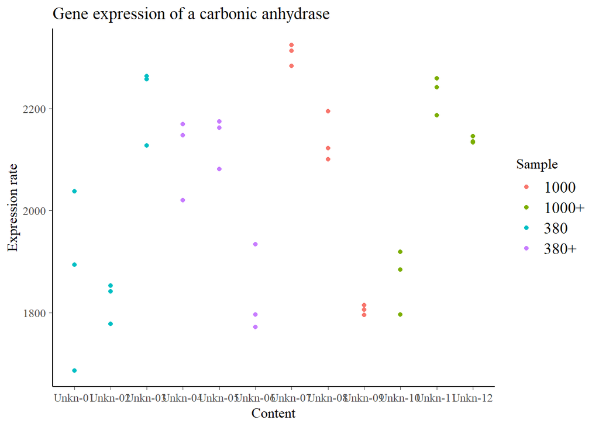

```r
ggplot(Gex2, aes(x=Content, y=End.RFU, group=Sample, color=Sample)) +
  geom_point(aes(x=Content,y=End.RFU, colour=Sample)) +
       ggtitle("Gene expression of a carbonic anhydrase") +
    scale_y_continuous(name="Expression rate")
```

```r
  #scale_x_continuous(name="Content")
```

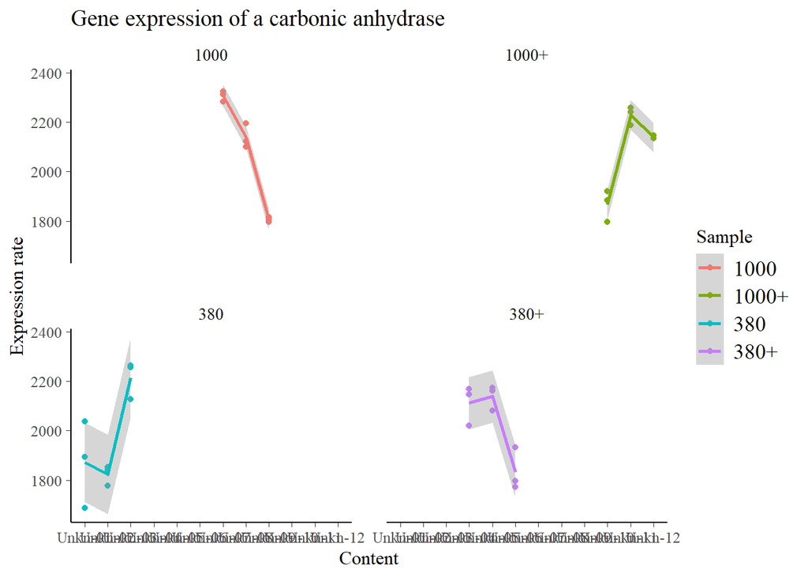

```r
ggplot(Gex2, aes(x=Content, y=End.RFU, group=Sample, color=Sample)) +
  geom_point(aes(x=Content,y=End.RFU, colour=Sample)) +
        facet_wrap(~Sample) +
  geom_smooth(aes(x=Content,y=End.RFU, colour=Sample)) +
       ggtitle("Gene expression of a carbonic anhydrase") +
    scale_y_continuous(name="Expression rate")
```

### Assumption 1: Individuals are independent:

How? By **centering** predictors, the interaction is independent. Use function center.

### Assumption 2: Variance is homogeneous:

**Homogeneity** is checked by validating a **boxplot**.

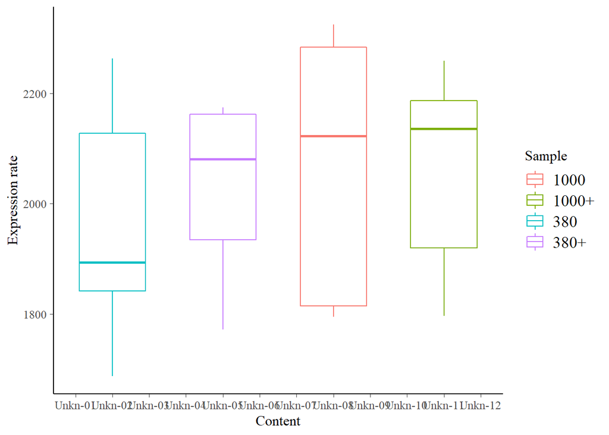

```r
ggplot(Gex2, aes(x=Content, y=End.RFU, group=Sample, color=Sample)) +
  geom_boxplot() +
    scale_y_continuous(name="Expression rate")
```

**Result**: I have homogeneity since there is no relation between the mean and the variance visible in the boxplot. I don’t have zeros. (Does it matter, if I have a rate?) Since I have two factors, I decide to run a two-way ANOVA. But first I will fit a linear model.

I think this is a hint to a not normal distributed dataset, because the Whiskers (lines) are not always the same length and the Quantiles are not equally to each others neither. The mean is not in the middle.

### Assumption 3: Residuals follow a normal distribution:

For this, we check on the QQ-Plot and do the pearson chi square test.

1. Fit a linear model

```r
Gex2.lm<-lm(End.RFU~Sample, data=Gex2)
```

Check on **coefficients** of the linear model:

```r
coef(Gex2.lm)
```

```
## (Intercept) Sample1000+   Sample380  Sample380+
##  2083.82645    -5.82836  -112.68384   -55.23050
```

Check on **residuals** of the linear model:

```r
r<-residuals(Gex2.lm)
r
```

```
##          1          2          3          4          5          6
##   66.82977 -283.91167  -77.12986 -268.73738 -277.44047 -288.44577
##          7          8          9         10         11         12
## -193.14686 -117.61983 -129.27590 -158.48587 -193.26548 -281.63095
##         13         14         15         16         17         18
##  156.43617  291.98746  285.83071  180.66728  108.72698  163.13303
##         19         20         21         22         23         24
##   -8.58963  119.21988  140.37111   57.41148   55.97753   67.46600
##         25         26         27         28         29         30
##   52.35036  133.48795  145.72472 -256.48176 -231.74455  -94.33808
##         31         32         33         34         35         36
##  199.53039  240.47963  229.06099   16.24853   38.42409  110.88000
```

2. Validate linear model:

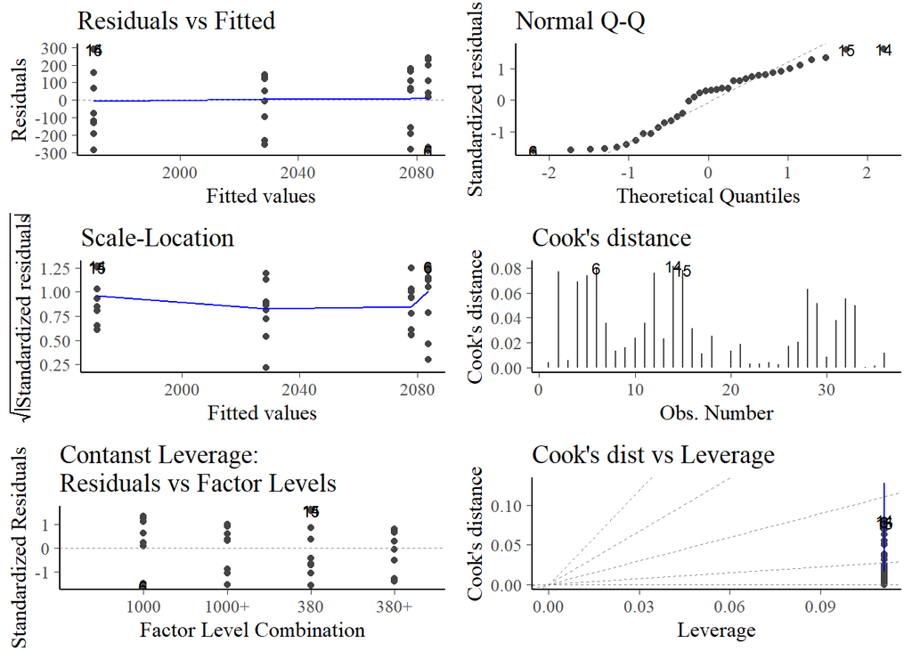

```r
autoplot(Gex2.lm, which=1:6, ncol=2, label.size=3)
```

**Result**: I have a pattern in my residuals vs. fitted graph. So I do not have homogeneity? Is the Normal QQ Plot, which compares the quantiles with the normal expected data, ok, or are these already tails?

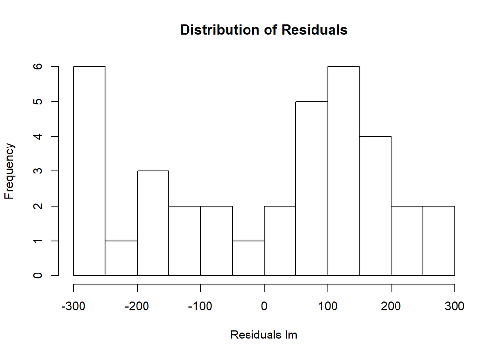

```r
hist(r, breaks=15, main="Distribution of Residuals", xlab="Residuals lm")
```

**Result**: Seems like also here is a bimodal distribution. So my data is not normally distributed.

Do a **Chi-square-test** :

```r
Gex2.resid<-sum(resid(Gex2.lm, type="pearson")^2)
1-pchisq(Gex2.resid, Gex2.lm$df.resid)
```

```
## [1] 0
```

**Result**: The value 0 tells me I have a lack of fit. Is my data normally distributed? Let’s check with a Shapiro-Wilk test. The higher the W statistic the “more normal” the data. But if the p-value is less than the chosen alpha level (=w), then the null hypothesis is rejected and there is evidence that the data tested are not normally distributed.

The test rejects the hypothesis of normality when the p-value is less than or equal to 0.05. Failing the normality test allows you to state with 95% confidence the data does not fit the normal distribution.

```r
#shapiro.test(End.RFU)
```

1. Fit log transformed lm:

Maybe if I log **transform** my data, they are normally distributed.

```r
Gex2.lm1<-lm(log(End.RFU)~Sample, data=Gex2)
```

2. Validate log transformed lm:

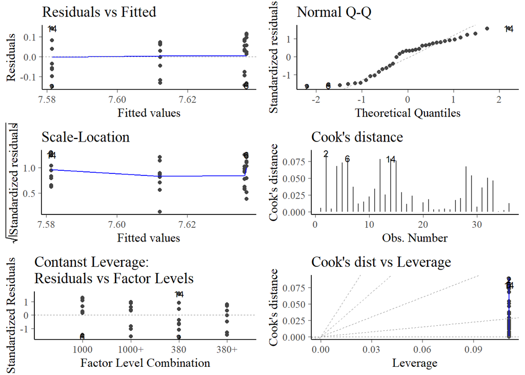

```r
autoplot(Gex2.lm1, which=1:6, ncol=2, label.size=3)
```

**Result** : I have a pattern still in my residuals plot.

Do a **Chi-square-test** :

```r
Gex2.resid<-sum(resid(Gex2.lm1, type="pearson")^2)
1-pchisq(Gex2.resid, Gex2.lm1$df.resid)
```

```
## [1] 1
```

**Result**: Now my data seems to be normally distributed, because the goodness of fit gives me 1 as the resulting value. And I have an independent variable?

### Multiple Linear Regression

Does not apply, if I assume levels for my experimental design

Maybe I try a **multiple linear regression**. So we check for linearity (relationship between the independent and dependent variables to be linear) with a scatterplot.

http://www.stat.yale.edu/Courses/1997-98/101/linmult.htm

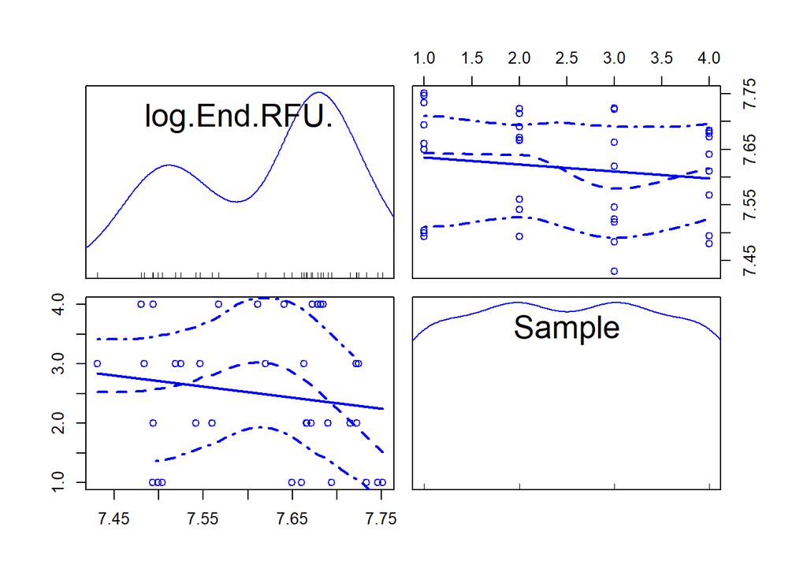

```r
scatterplotMatrix(~log(End.RFU)+Sample, data=Gex2, diagonal='boxplot')
```

**Result** : Seems like the overall relation is linear. The expression decreases when taking into account nutrients and/or CO2. But can I ignore the bump in the End.RFU=Expressoin rate? I have two means, do I have to split my dataset??? Maybe into low CO2 and high CO2? I have a **bimodal distribution**.

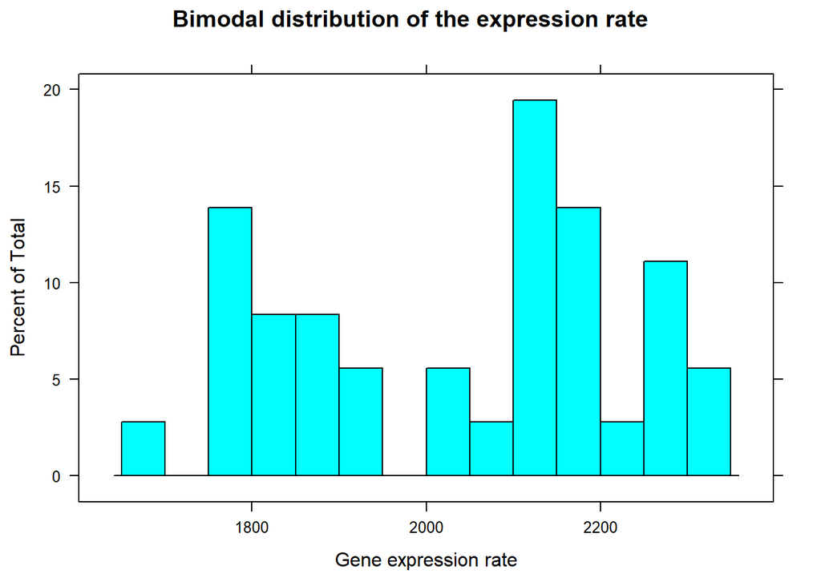

```r
attach(Gex2)
histogram(Gex2$End.RFU, breaks=15, main="Bimodal distribution of the expression rate", xlab="Gene expression rate")
```

The histogram to test for linearity gets created with the predictor values x?!

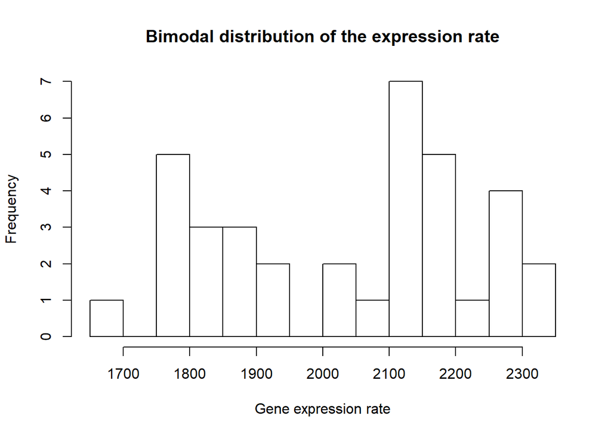

```r
hist(Gex2$End.RFU, breaks=15, main="Bimodal distribution of the expression rate", xlab="Gene expression rate")
```

Is the expression rate different for high and low CO2?

What is the mean expression rate in every sample/Treatment?

```r
aggregate(End.RFU~Sample, FUN=mean)
```

```
##   Sample  End.RFU
## 1   1000 2083.826
## 2  1000+ 2077.998
## 3    380 1971.143
## 4   380+ 2028.596
```

**Result** : Seems like the factor CO2 is having an impact on the expression rate. If the mean of the low CO2 treatment is lower, that’s how I get the bimodal distribution, right?

### Plot Ex against low CO2

Therefore, I need to use Sample 380 and 380+ only, so I subcreate Gex2 calling it Gex2LCO2.

```r
Gex2LCO2<-filter(Gex2, Sample %in% c('380','380+')) %>% droplevels()
Gex2LCO2
```

```
##    Content Sample  End.RFU
## 1  Unkn-01    380 2037.972
## 2  Unkn-01    380 1687.231
## 3  Unkn-01    380 1894.013
## 4  Unkn-02    380 1777.996
## 5  Unkn-02    380 1853.523
## 6  Unkn-02    380 1841.867
## 7  Unkn-03    380 2127.579
## 8  Unkn-03    380 2263.130
## 9  Unkn-03    380 2256.973
## 10 Unkn-04   380+ 2020.006
## 11 Unkn-04   380+ 2147.816
## 12 Unkn-04   380+ 2168.967
## 13 Unkn-05   380+ 2080.946
## 14 Unkn-05   380+ 2162.084
## 15 Unkn-05   380+ 2174.321
## 16 Unkn-06   380+ 1772.114
## 17 Unkn-06   380+ 1796.851
## 18 Unkn-06   380+ 1934.258
```

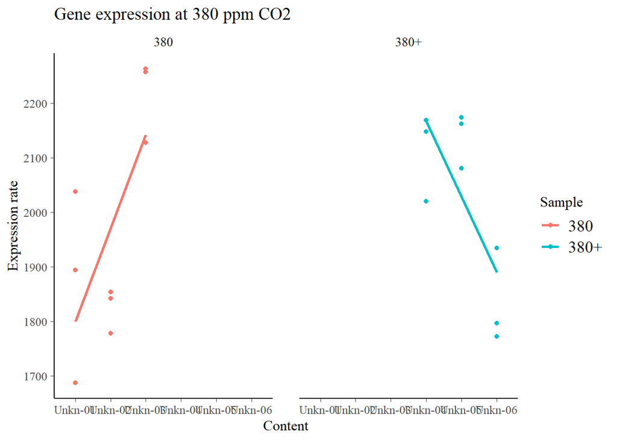

```r
ggplot(Gex2LCO2, aes(y=End.RFU, x=Content, group=Sample, color=Sample)) +
  geom_point()+
       ggtitle("Gene expression at 380 ppm CO2") +
    scale_y_continuous(name="Expression rate") +
  geom_smooth(method='lm', se=FALSE) +
  facet_wrap(~Sample)
```

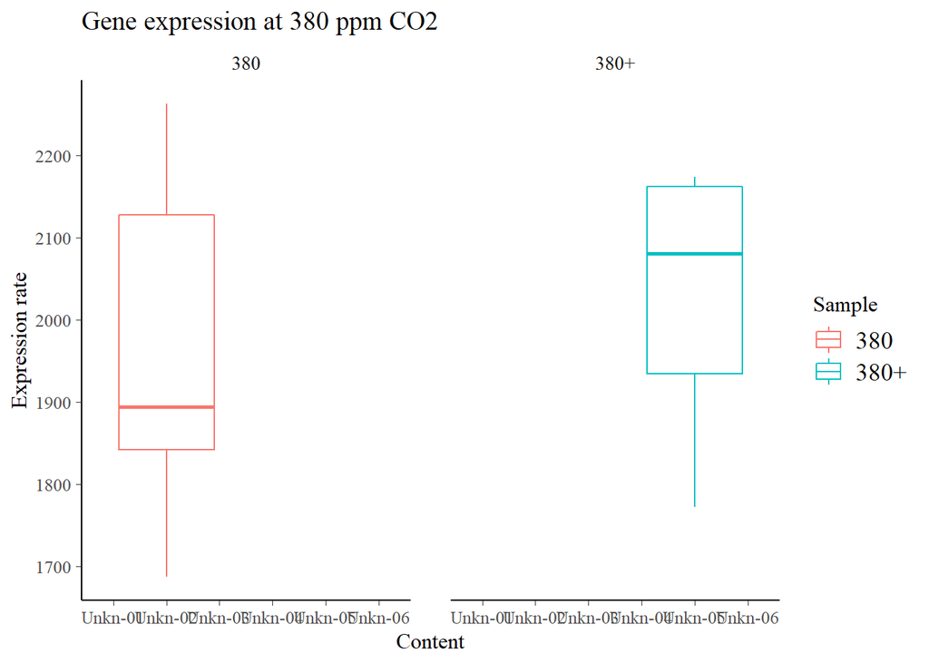

```r
ggplot(Gex2LCO2, aes(y=End.RFU, x=Content, group=Sample, color=Sample)) +
  geom_boxplot()+
       ggtitle("Gene expression at 380 ppm CO2") +
    scale_y_continuous(name="Expression rate") +
  facet_wrap(~Sample)
```

### Plot Ex against high CO2

Therefore, I need to use Sample 1000 and 1000+ only, so I subcreate Gex2 calling it Gex2HCO2.

```r
Gex2HCO2<-filter(Gex2, Sample %in% c('1000','1000+')) %>% droplevels()
Gex2HCO2
```

```
##    Content Sample  End.RFU
## 1  Unkn-09   1000 1815.089
## 2  Unkn-09   1000 1806.386
## 3  Unkn-09   1000 1795.381
## 4  Unkn-10  1000+ 1919.512
## 5  Unkn-10  1000+ 1884.733
## 6  Unkn-10  1000+ 1796.367
## 7  Unkn-11  1000+ 2258.665
## 8  Unkn-11  1000+ 2186.725
## 9  Unkn-11  1000+ 2241.131
## 10 Unkn-12  1000+ 2135.410
## 11 Unkn-12  1000+ 2133.976
## 12 Unkn-12  1000+ 2145.464
## 13 Unkn-07   1000 2283.357
## 14 Unkn-07   1000 2324.306
## 15 Unkn-07   1000 2312.887
## 16 Unkn-08   1000 2100.075
## 17 Unkn-08   1000 2122.251
## 18 Unkn-08   1000 2194.706
```

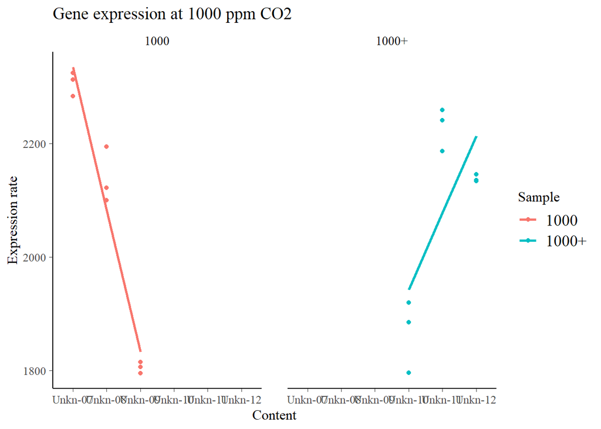

```r
ggplot(Gex2HCO2, aes(y=End.RFU, x=Content, group=Sample, color=Sample)) +
  geom_point()+
       ggtitle("Gene expression at 1000 ppm CO2") +
    scale_y_continuous(name="Expression rate") +
  geom_smooth(method='lm', se=FALSE) +
  facet_wrap(~Sample)
```

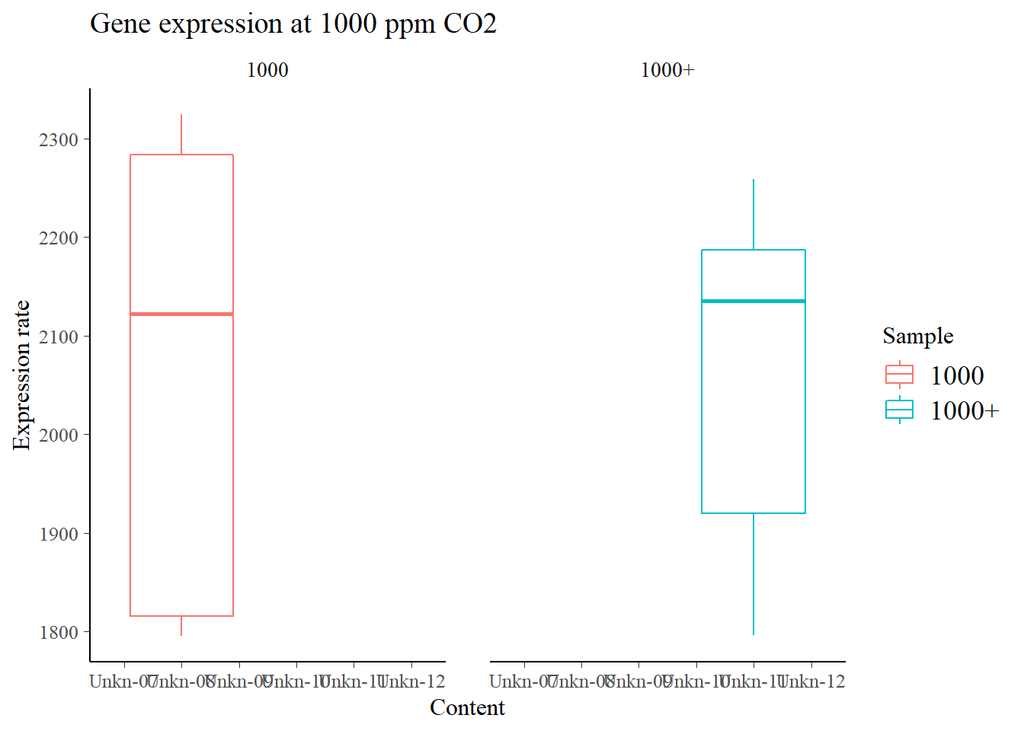

```r
ggplot(Gex2HCO2, aes(y=End.RFU, x=Content, group=Sample, color=Sample)) +
  geom_boxplot()+
       ggtitle("Gene expression at 1000 ppm CO2") +
    scale_y_continuous(name="Expression rate") +
  facet_wrap(~Sample)
```

Two peaks could also indicate your data is sinusoidal. If you suspect your data might be following a wave-like pattern, create a scatter plot or a run sequence plot to double-check for sinusoidal patterns. You could also make a lag plot (verzoegert); an elliptical (oval) pattern would confirm that the data is sinusoidal.

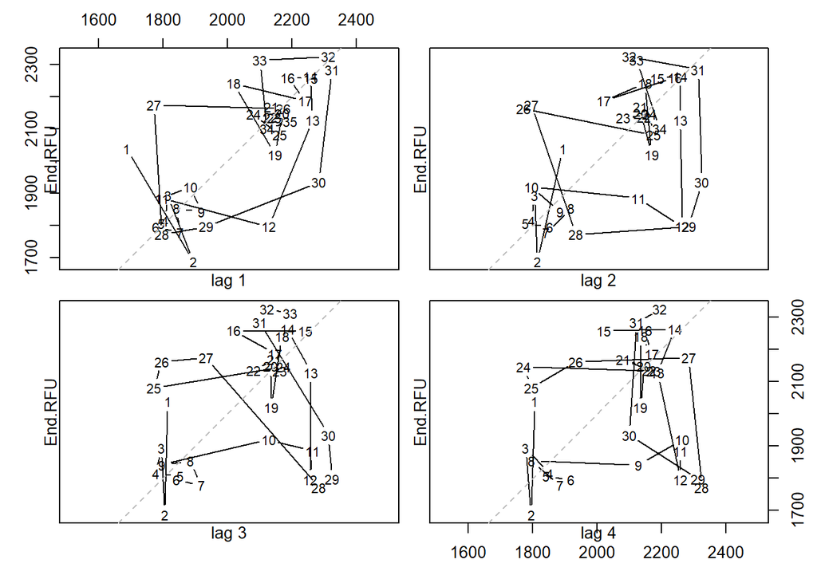

```r
lag.plot(End.RFU, lags=4)
```

**Result** : Does that count as elliptical shape to confirm the data is sinusoidal?

What now?

### Mixtools

In order to fit a bimodial distribution data, I use this function.

```r
Gex2.mixmdl <- normalmixEM(Gex2$End.RFU, lambda=c(0.83, 0.17), mu=c(2090.95, 1794.35), sigma=c(163.67, 13.68))
```

```
## number of iterations= 4
```

**Result**: 4 iterations means?

In this way I get the parameters, that I can enter into the fit above:

```r
Gex2.mixmdl[c("lambda", "mu", "sigma")]
```

```
## $lambda
## [1] 0.8295401 0.1704599
##
## $mu
## [1] 2090.950 1794.346
##
## $sigma
## [1] 163.67169  13.68409
```

```r
summary(Gex2.mixmdl)
```

```
## summary of normalmixEM object:
##            comp 1     comp 2
## lambda    0.82954    0.17046
## mu     2090.94975 1794.34594
## sigma   163.67169   13.68409
## loglik at estimate:  -233.1667
```

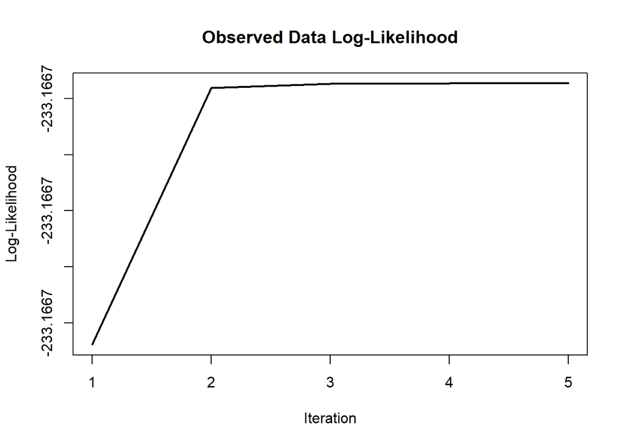

```r
plot(Gex2.mixmdl)
```

Plot the model:

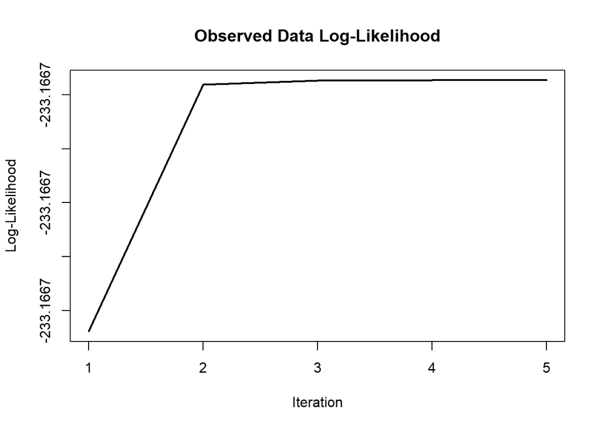

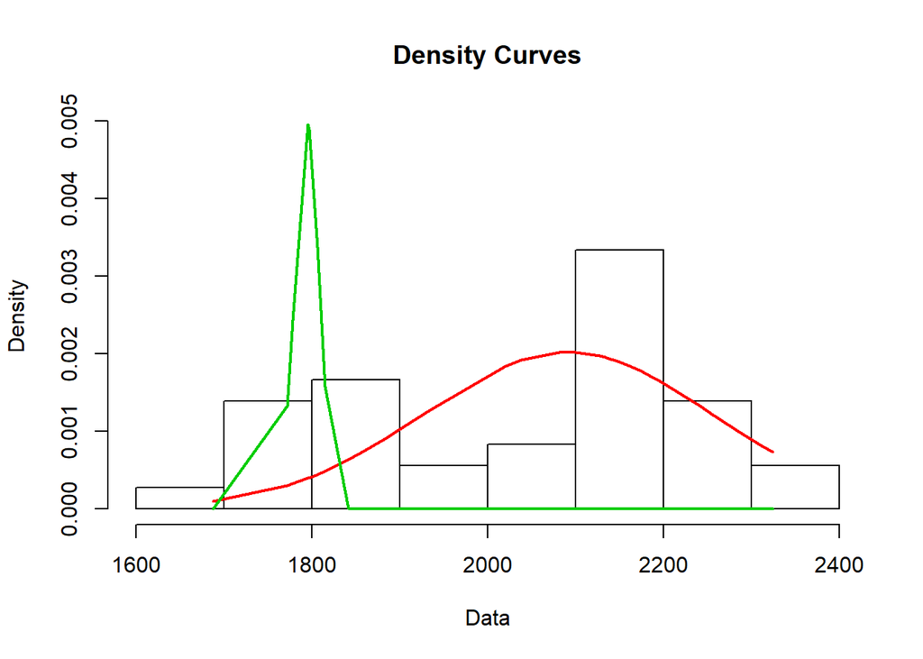

```r
# cex tells you how big to magnify a text, default is 1; cex.main is for titles, lab for labels and axis for axes
plot(Gex2.mixmdl, density = TRUE)
```

**Result** : The red curve doesn’t quiet show the correct distribution. Neither the green one really.

Validate the model with a chi square test.

```r
#Gex2.mix.resid<-sum(resid(Gex2.mixmdl, type="pearson")^2)
#1-pchisq(Gex2.mix.resid, Gex2.mixmdl$df.resid) # Error in pchisq(Gex2.mix.resid, Gex2.mixmdl$df.resid) : Non-numeric argument to mathematical function
```

Compare the model with AIC:

```r
#AIC(Gex2.mixmdl, Gex2.lm) # Error in UseMethod("logLik") : no applicable method for 'logLik' applied to an object of class "mixEM"
#multmixmodel.sel(Gex2.mixmdl, comps=1:4, epsilon=0.001) # Error in apply(y, 1, sum) : dim(X) must have a positive length
```

Parametric Bootstrap method is a variance estimation, which might help me to validate my mixed model? We want a small variance, so that the data points are close to the mean.

I worked accroding to this link: https://cran.r-project.org/web/packages/mixtools/vignettes/mixtools.pdf

```r
#regmixEM(End.RFU, Sample, lambda=c(0.75, 0.25), beta=c(2037.20, 2354.09), sigma=c(164.06, 21.34), k=2)
```

What is label-switching in stats?

```r
#set.seed(seed) Set the seed of R's random number generator,
set.seed(123)
Gex2boot <- boot.se(Gex2.mixmdl, B = 1000)
```

[output not shown]

[output cut: 953 more lines]

[output not shown]

```r
rbind(range(Gex2boot$beta[1,]), range(Gex2boot$beta[2,]))
```

```
##      [,1] [,2]
## [1,]  Inf -Inf
## [2,]  Inf -Inf
```

```r
Gex2boot[c("lambda.se", "beta.se", "sigma.se")]
```

```
## $lambda.se
## [1] 0.06851556 0.06851556
##
## $<NA>
## NULL
##
## $sigma.se
## [1] 22.612565  7.207876
```

What now?

### Two factorial ANOVA

This shows exactly my experimental design:

http://www.flutterbys.com.au/stats/tut/tut7.6a.html

Hypothesis tests assume that the residuals are:

```
- normally distributed. Boxplots using the appropriate scale of replication (reflecting the appropriate residuals/F-ratio denominator (see table above) should be used to explore normality. Scale transformations are often useful
- equally varied/homogeneity. Boxplots and plots of means against variance (using the appropriate scale of replication) should be used to explore the spread of values. Residual plots should reveal no patterns. Scale transformations are often useful
- independent of one another
- balanced
```

BUT: Can I run an ANOVA when it assumes normal distribution, when I have a bimodal distribution?? I guess no.

A boxplots shows, if I have normality, when $ y ~ A * B $, where y is my Ex, A my first factor CO2 and B my second factor nutrient. How can I use CO2 and nutrients as vectors??

CO2 is Sample 380 ~ 1000 or treatment A+B ~ C+D

Nut is NA ~ + or treatment A+C ~ B+D

I will correct my excel sheet called “ca” and order it in this way (similar to the quinn dataset):

I implement CO2 high or low and Nutrients high or low as FACTORS!

```r
head(Gex2.lm)
```

[output not shown]

```r
# 1000 is the intercept!!!
```

```r
#ggplot(Gex2, aes(y = End.RFU, x = , fill = B)) +
  #geom_boxplot()
```

### One-way ANOVA

Just to give it a try, I will run a ONe-way ANOVA with my logtransformed data Gex2.lm1:

```r
anova(Gex2.lm1)
```

```
## Analysis of Variance Table
##
## Response: log(End.RFU)
##           Df   Sum Sq   Mean Sq F value Pr(>F)
## Sample     3 0.018414 0.0061378  0.6732 0.5748
## Residuals 32 0.291767 0.0091177
```

**Result** : Since the p-value is over 0.05, I don’t have a significant effect. So, I will skip the pairwise comparison and try to investigate further the single impact of nutrients and CO2 as numerical factors.

## ca dataset

I guess to give this more sense for interpretation, I should implement my predictors into the gene expression data, such as nitrate, phosphate, pH, salinity, alkalinity and CO2 partial pressure in ppm and just to be sure also the light intensity. So I will create a new csv file containing the information of Gex.csv and incorporate the information of my parameters. I will call this new csv file ‘ca’ for carbonic anhydrase. This dataset includes the gene expression rates AND the parameteres influencing this response.

So, my response is the gene expression and the predictors are several. The main drivers I expect to be nutrients and CO2 (TA). These are my factors, having two levels each - low and high. In total I have 4 treatments, while A and B have low CO2 levels (380ppm) and C and D have high CO2 levels (1000ppm). A stands for low nutrient levels (NO3: 1µM and PO4 3-: 0.2µM) and a partial pressure of CO2 of 380 ppm. B) stands for high nutrient levels (NO3: 10µM and PO4 3-: 2µM) and 380 ppm; C) means low nutrient levels and 1000 ppm and D) has high nutrient levels and 1000 ppm.

I should do a **multiple linear (or non-linear) regression** with my numerical explainatory variables.

But first, let’s have a look at the new dataset:

### Load and have a look at the dataset:

```r
ca<-read.csv('C:/Users/admin/Desktop/Paper CA/Gex/ca.csv', strip.white=T)
head(ca)
```

```
##   Content Treatment ppm nut       Ex  Light Temp  Sal  pH  TA   NO3  PO43
## 1 Unkn-01         A low low 2037.972 148.12 25.8 35.3 7.7 425 5.349 0.153
## 2 Unkn-01         A low low 1687.231 148.12 25.8 35.3 7.7 425 5.349 0.153
## 3 Unkn-01         A low low 1894.013 148.12 25.8 35.3 7.7 425 5.349 0.153
## 4 Unkn-02         A low low 1777.996 176.12 25.8 35.2 7.7 360 3.168 0.135
## 5 Unkn-02         A low low 1853.523 176.12 25.8 35.2 7.7 360 3.168 0.135
## 6 Unkn-02         A low low 1841.867 176.12 25.8 35.2 7.7 360 3.168 0.135
```

```r
glimpse(ca)
```

```
## Observations: 36
## Variables: 12
## $ Content   <fct> Unkn-01, Unkn-01, Unkn-01, Unkn-02, Unkn-02, Unkn-02...
## $ Treatment <fct> A, A, A, A, A, A, A, A, A, B, B, B, B, B, B, B, B, B...
## $ ppm       <fct> low, low, low, low, low, low, low, low, low, low, lo...
## $ nut       <fct> low, low, low, low, low, low, low, low, low, high, h...
## $ Ex        <dbl> 2037.972, 1687.231, 1894.013, 1777.996, 1853.523, 18...
## $ Light     <dbl> 148.12, 148.12, 148.12, 176.12, 176.12, 176.12, 143....
## $ Temp      <dbl> 25.8, 25.8, 25.8, 25.8, 25.8, 25.8, 25.8, 25.8, 25.8...
## $ Sal       <dbl> 35.3, 35.3, 35.3, 35.2, 35.2, 35.2, 35.3, 35.3, 35.3...
## $ pH        <dbl> 7.7, 7.7, 7.7, 7.7, 7.7, 7.7, 7.7, 7.7, 7.7, 7.7, 7....
## $ TA        <int> 425, 425, 425, 360, 360, 360, 430, 430, 430, 460, 46...
## $ NO3       <dbl> 5.349, 5.349, 5.349, 3.168, 3.168, 3.168, 5.433, 5.4...
## $ PO43      <dbl> 0.153, 0.153, 0.153, 0.135, 0.135, 0.135, 0.182, 0.1...
```

```r
# fct = characters = variables      = Content, Treat
# dbl = double = decimals           = Ex, Light, Temp, Sal, pH, NO3, PO43
# int = integers = whole numbers    = TA
```

```r
summary(ca)
```

```
##     Content   Treatment   ppm       nut           Ex           Light
##  Unkn-01: 3   A:9       high:18   high:18   Min.   :1687   Min.   :143.2
##  Unkn-02: 3   B:9       low :18   low :18   1st Qu.:1851   1st Qu.:152.2
##  Unkn-03: 3   C:9                           Median :2111   Median :166.4
##  Unkn-04: 3   D:9                           Mean   :2040   Mean   :165.4
##  Unkn-05: 3                                 3rd Qu.:2177   3rd Qu.:176.7
##  Unkn-06: 3                                 Max.   :2324   Max.   :190.3
##  (Other):18
##       Temp           Sal              pH            TA
##  Min.   :25.8   Min.   :35.20   Min.   :7.3   Min.   :360.0
##  1st Qu.:25.8   1st Qu.:35.30   1st Qu.:7.3   1st Qu.:425.0
##  Median :25.8   Median :35.55   Median :7.5   Median :437.5
##  Mean   :25.8   Mean   :35.48   Mean   :7.5   Mean   :457.1
##  3rd Qu.:25.8   3rd Qu.:35.62   3rd Qu.:7.7   3rd Qu.:460.0
##  Max.   :25.8   Max.   :35.80   Max.   :7.7   Max.   :750.0
##
##       NO3             PO43
##  Min.   :2.583   Min.   :0.1170
##  1st Qu.:5.196   1st Qu.:0.1477
##  Median :6.153   Median :0.3250
##  Mean   :6.296   Mean   :0.3863
##  3rd Qu.:7.645   3rd Qu.:0.6115
##  Max.   :9.834   Max.   :0.7430
##
```

```r
str(ca)
```

```
## 'data.frame':    36 obs. of  12 variables:
##  $ Content  : Factor w/ 12 levels "Unkn-01","Unkn-02",..: 1 1 1 2 2 2 3 3 3 4 ...
##  $ Treatment: Factor w/ 4 levels "A","B","C","D": 1 1 1 1 1 1 1 1 1 2 ...
##  $ ppm      : Factor w/ 2 levels "high","low": 2 2 2 2 2 2 2 2 2 2 ...
##  $ nut      : Factor w/ 2 levels "high","low": 2 2 2 2 2 2 2 2 2 1 ...
##  $ Ex       : num  2038 1687 1894 1778 1854 ...
##  $ Light    : num  148 148 148 176 176 ...
##  $ Temp     : num  25.8 25.8 25.8 25.8 25.8 25.8 25.8 25.8 25.8 25.8 ...
##  $ Sal      : num  35.3 35.3 35.3 35.2 35.2 35.2 35.3 35.3 35.3 35.7 ...
##  $ pH       : num  7.7 7.7 7.7 7.7 7.7 7.7 7.7 7.7 7.7 7.7 ...
##  $ TA       : int  425 425 425 360 360 360 430 430 430 460 ...
##  $ NO3      : num  5.35 5.35 5.35 3.17 3.17 ...
##  $ PO43     : num  0.153 0.153 0.153 0.135 0.135 0.135 0.182 0.182 0.182 0.607 ...
```

### Visualize the dataset

These two should look the same:

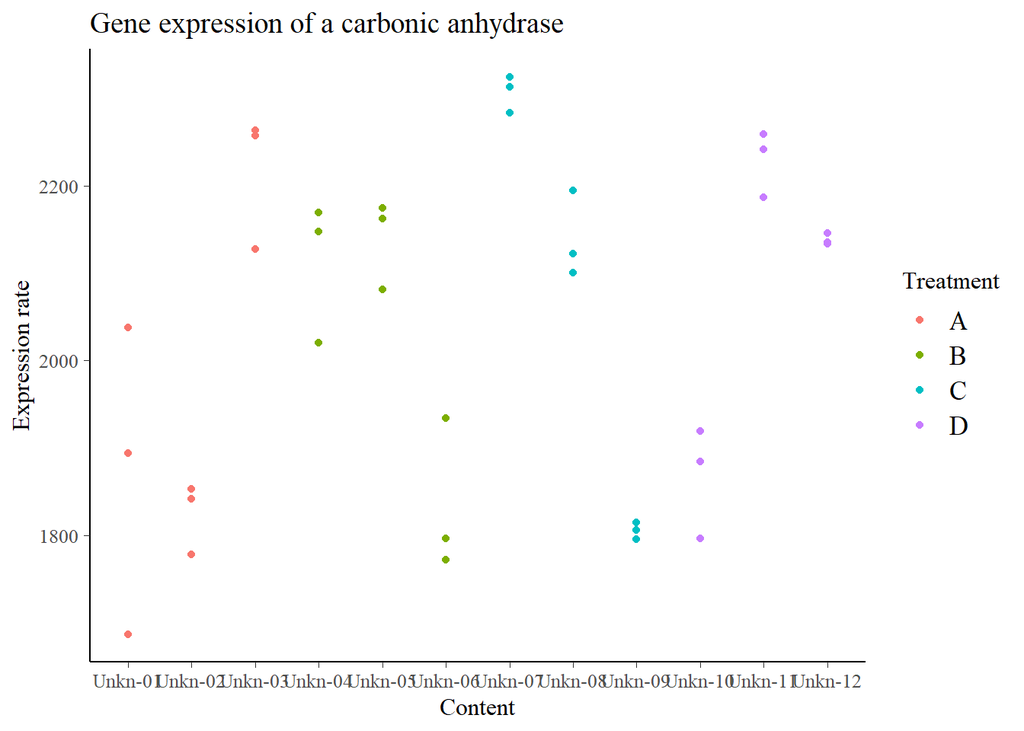

```r
ggplot(ca, aes(x=Content, y=Ex, group=Treatment, color=Treatment)) +
  geom_point(aes(x=Content, y=Ex, group=Treatment, color=Treatment)) +
       ggtitle("Gene expression of a carbonic anhydrase") +
    scale_y_continuous(name="Expression rate")
```

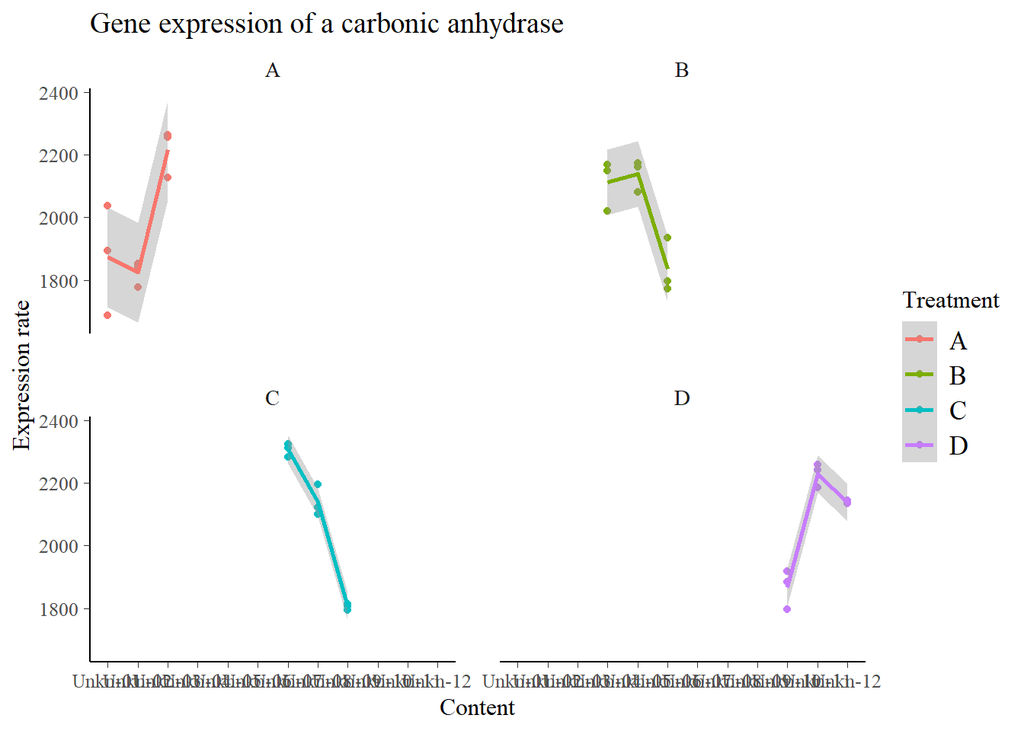

```r
ggplot(ca, aes(x=Content, y=Ex, group=Treatment, color=Treatment)) +
  geom_point(aes(x=Content,y=Ex, group=Treatment, color=Treatment)) +
        facet_wrap(~Treatment) +
  geom_smooth(aes(x=Content,y=Ex, group=Treatment, color=Treatment)) +
       ggtitle("Gene expression of a carbonic anhydrase") +
    scale_y_continuous(name="Expression rate")
```

**Result** : This is equal to the Gex2 dataset. These are not the up and down regulations, but I can see that the expression rates in every treatment are all around 2000, which is also stated in the summary: mean of Ex = 2040. I wonder, if there is a significant difference of the expression rates between the treatments.

### Plots

Ex against CO2 levels:

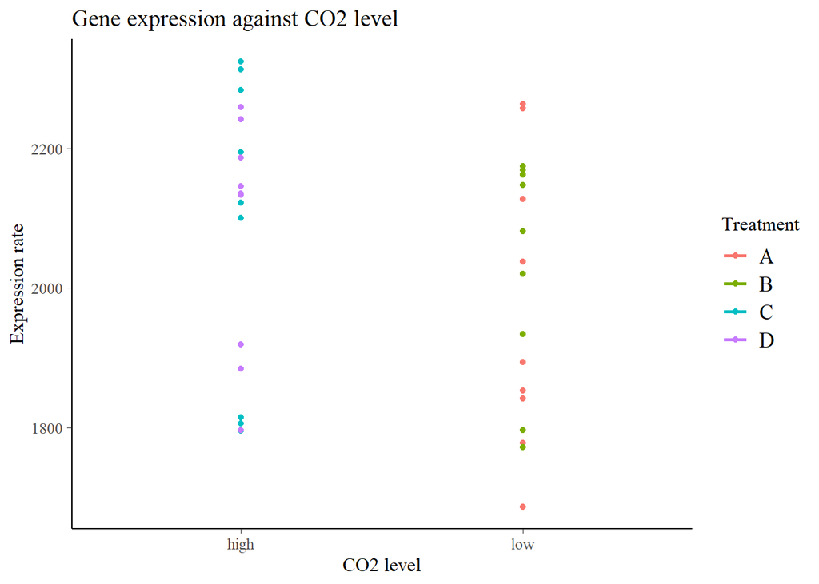

```r
ggplot(ca, aes(y=Ex, x=ppm, colour=Treatment)) +
        geom_point() +
  geom_smooth(method='lm', se=FALSE) +
        scale_y_continuous(name="Expression rate") +
        scale_x_discrete(name="CO2 level") +
       ggtitle("Gene expression against CO2 level")
```

Ex against Nutrient levels:

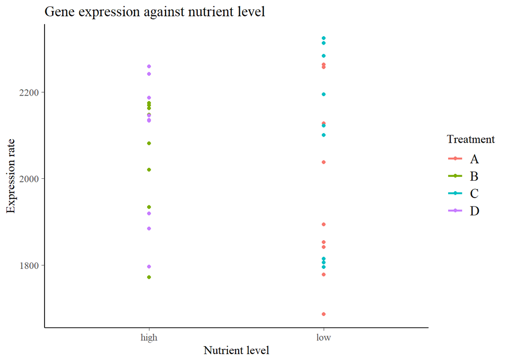

```r
ggplot(ca, aes(y=Ex, x=nut, colour=Treatment)) +
        geom_point() +
  geom_smooth(method='lm', se=FALSE) +
        scale_y_continuous(name="Expression rate") +
        scale_x_discrete(name="Nutrient level") +
       ggtitle("Gene expression against nutrient level")
```

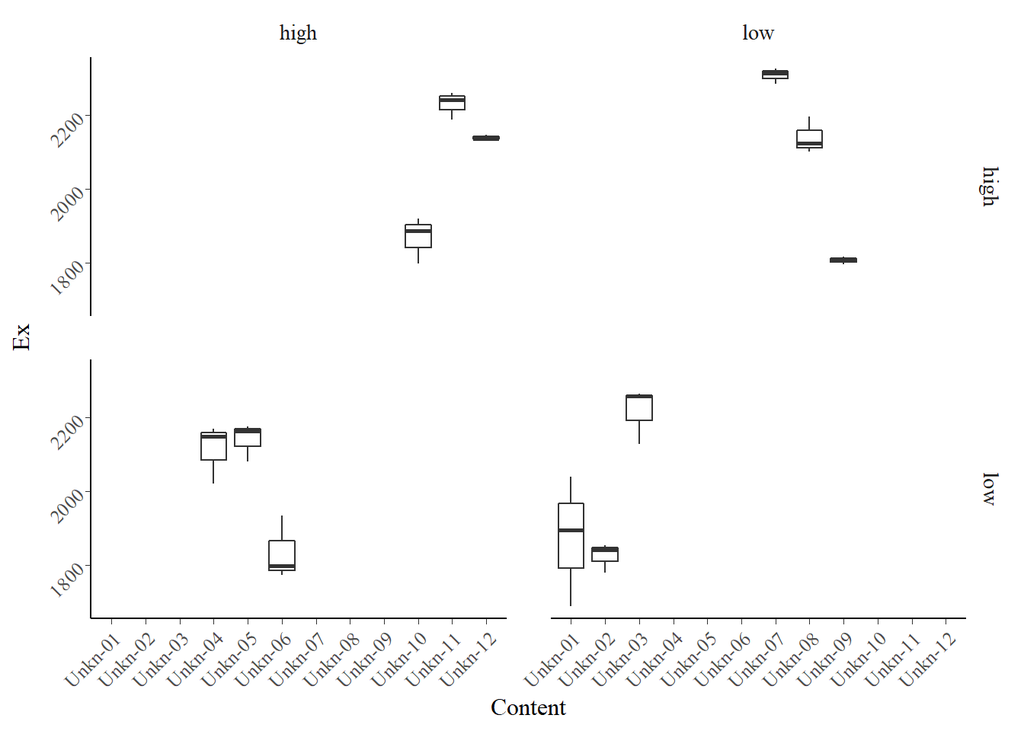

```r
ggplot(data=ca) +
  geom_boxplot(aes(y=Ex, x=Content)) +
  facet_grid(ppm~nut) +
  theme(axis.text=element_text(angle=45, hjust=1)) # it changes the angle of the label in the axes
```

For each treatment:

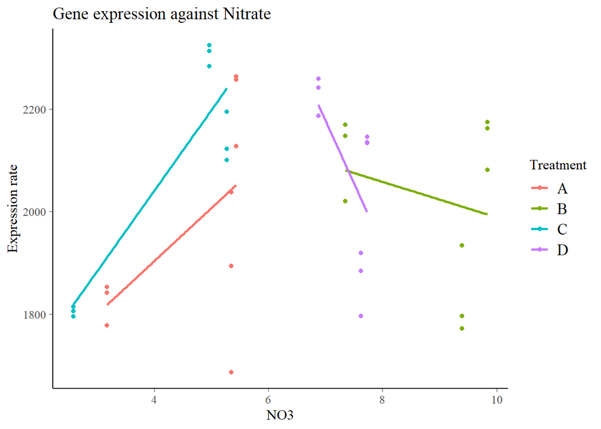

```r
ggplot(ca, aes(y=Ex, x=NO3, colour=Treatment)) +
        geom_point() +
  geom_smooth(method='lm', se=FALSE) +
        scale_y_continuous(name="Expression rate") +
       ggtitle("Gene expression against Nitrate")
```

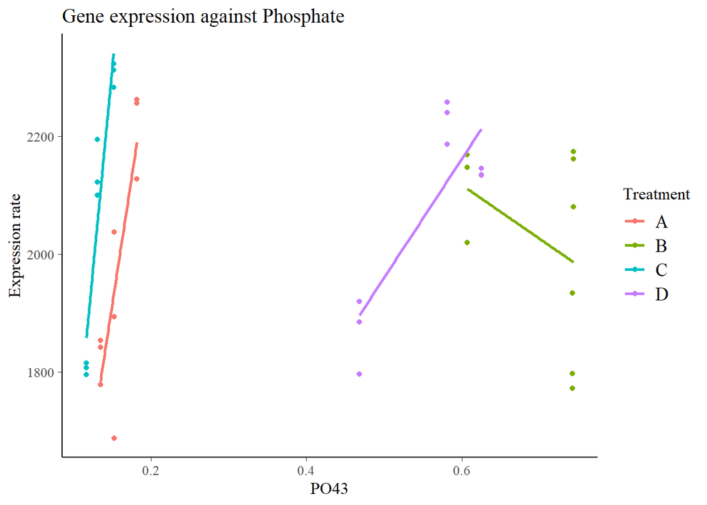

```r
ggplot(ca, aes(y=Ex, x=PO43, colour=Treatment)) +
        geom_point() +
    geom_smooth(method='lm', se=FALSE) +
        scale_y_continuous(name="Expression rate") +
       ggtitle("Gene expression against Phosphate")
```

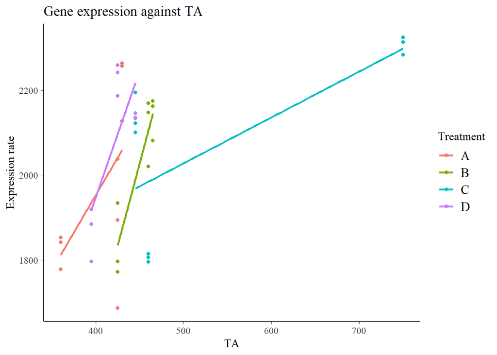

```r
ggplot(ca, aes(y=Ex, x=TA, colour=Treatment)) +
        geom_point() +
  geom_smooth(method='lm', se=FALSE) +
        scale_y_continuous(name="Expression rate") +
       ggtitle("Gene expression against TA")
```

Normal distribution is not quiet visible. Maybe I log transform my data?

Remember, that A (the control) has low nutrient levels, same as C.

For every single parameter in general: (dependency and linearity)

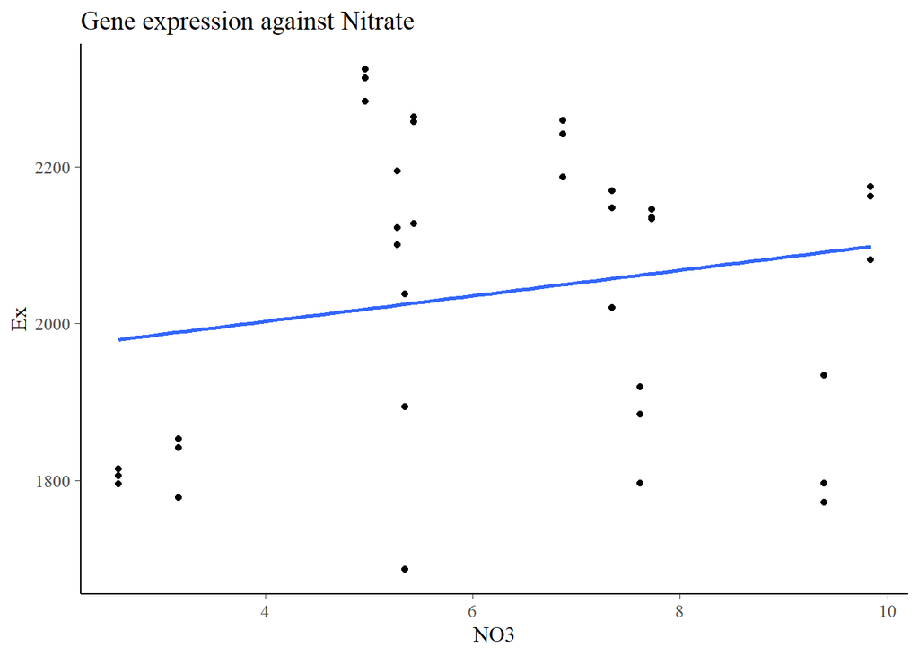

```r
ggplot(ca, aes(y=Ex, x=NO3)) +
  geom_point() +
  geom_smooth(method='lm', se=FALSE) +
       ggtitle("Gene expression against Nitrate")
```

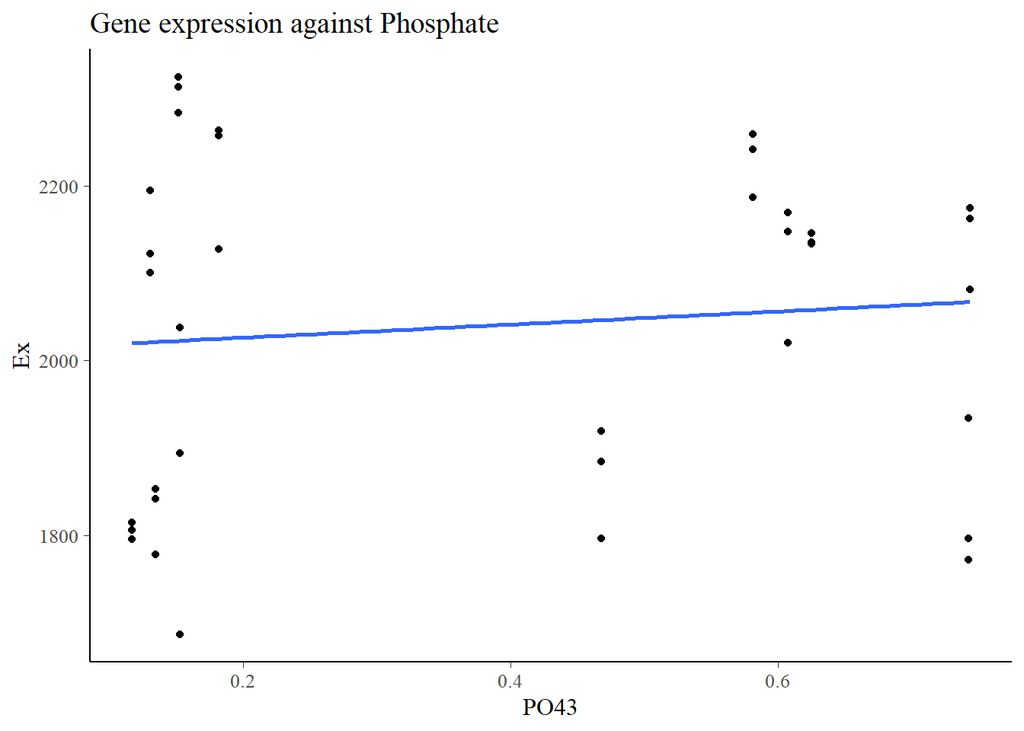

```r
ggplot(ca, aes(y=Ex, x=PO43)) +
  geom_point() +
  geom_smooth(method='lm', se=FALSE) +
       ggtitle("Gene expression against Phosphate")
```

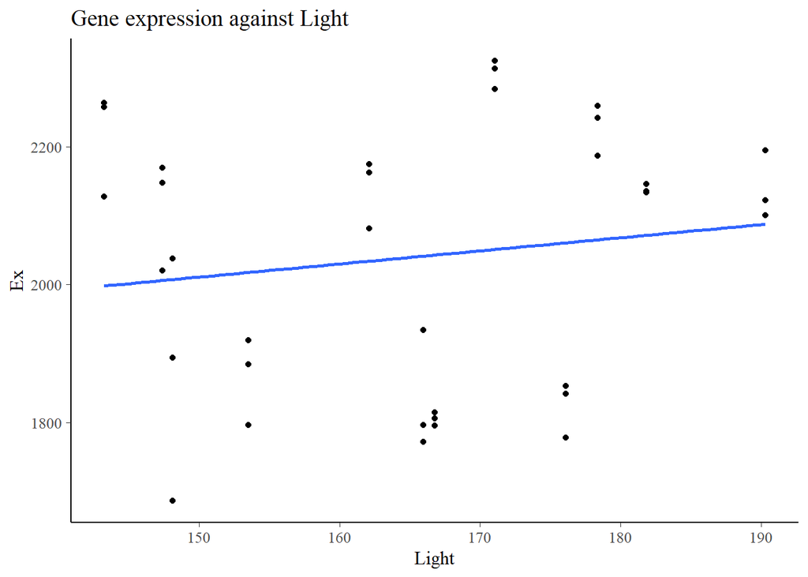

```r
ggplot(ca, aes(y=Ex, x=Light)) +
  geom_point() +
  geom_smooth(method='lm', se=FALSE) +
       ggtitle("Gene expression against Light")
```

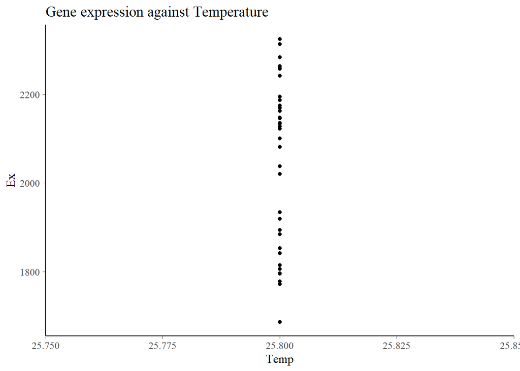

```r
ggplot(ca, aes(y=Ex, x=Temp)) +
  geom_point() +
  geom_smooth(method='lm', se=FALSE) +
       ggtitle("Gene expression against Temperature")
```

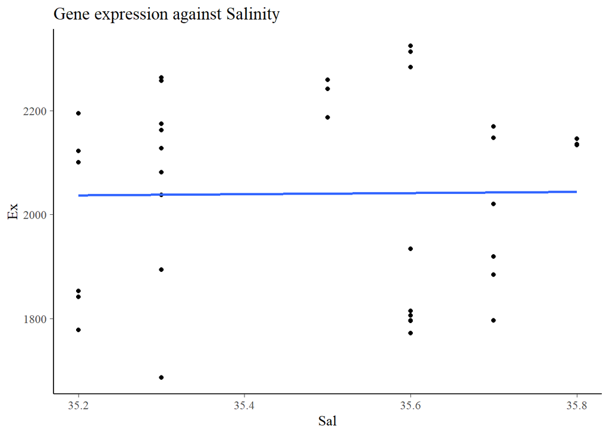

```r
ggplot(ca, aes(y=Ex, x=Sal)) +
  geom_point() +
  geom_smooth(method='lm', se=FALSE) +
       ggtitle("Gene expression against Salinity")
```

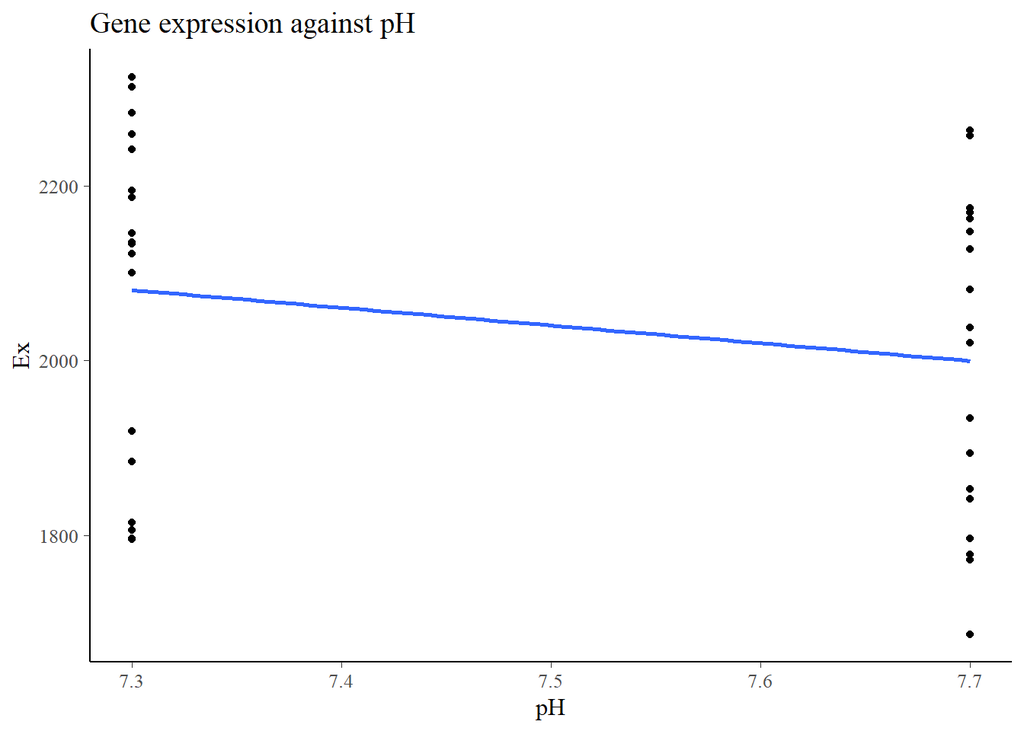

```r
ggplot(ca, aes(y=Ex, x=pH)) +
  geom_point() +
  geom_smooth(method='lm', se=FALSE) +
       ggtitle("Gene expression against pH")
```

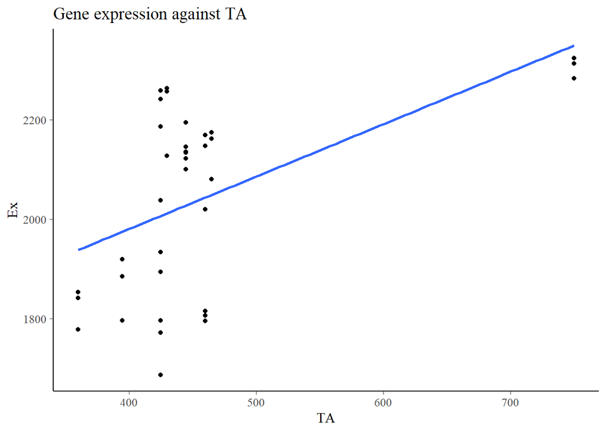

```r
ggplot(ca, aes(y=Ex, x=TA)) +
  geom_point() +
  geom_smooth(method='lm', se=FALSE) +
       ggtitle("Gene expression against TA")
```

Note: instead of doing this manually, you could use the scatterplotMatrix. It is exactly that! But I want to know, whether the RESIDUALS follow a normal distribution!?